# Lab 2B: Intro to Data (part 2)

Intro Stats

Fall 2018

In this lab, we’ll continue to look at the Behavioral Risk Factor Surveillance System (BRFSS) dataset. Go ahead and import the data, and load the tidyverse package.

*Instructions:* Record your answers to the exercises and the OYO section in one word processing document. Submit this to your instructor electronically.

Recall from the previous lab that some of the variables were quantitative and some were categorical. The categorical variables are: genhlth, exerany, hlthplan, smoke100, and gender.

1. What do you notice about the possible values that the categorical variables can take? For example, compare genhlth with hlthplan.

### Numerical Summaries

In the next labs, we’ll learn how to represent graphically quantitative and categorical variables. In this lab, we’ll learn how to dig deeper into the data by analyzing subgroups.

#### Summarize

Recall from the previous lab that if we wanted to find the mean height for everyone in the cdc dataset, we used the summarize command in this way:

```r
cdc %>%
  summarize(avg.height = mean(height))
```

Let’s say that we wanted to compare the heights of men and women in the survey. In this case, we would need to compare groups.

#### Group_by

The `group_by()` command lets us group our dataset by a categorical variable, like gender. If we group our dataset using `group_by()` before we summarize, we’ll summarize each group. For example:

```r
cdc %>%
  group_by(gender) %>%
  summarize(avg.height = mean(height))
```

2. What is the average height for females?

We can also group by multiple categorical variables - say we want to use both `hlthplan` and `gender`.

3. How many different groups will this give us?

If we want to group by both variables, we can put both of them in the `group_by()` command:

```r
cdc %>%
  group_by(hlthplan, gender) %>%
  summarize(avg.height = mean(height))
```

This can also be useful for counting the number of people in different groups:

```r
cdc %>%
  group_by(hlthplan, gender) %>%
  summarize(number = n())
```

4. What proportion of people in the study are female? male?

### Making new variables

You can make a new variable using the `mutate` command. For example, we might be interested in computing individuals’ Body Mass Index. The Body Mass Index (BMI) is a statistic calculated from the weight (in kg) and height (in cm) using the formula BMI= weight/(height^2). Or, using the appropriate conversions, the BMI can be calculated from weight (in pounds) and height (in inches) using the formula BMI= 703*weight/(height^2). You can learn more about the BMI at https://www.cdc.gov/healthyweight/assessing/bmi/index.html.

To compute this variable we can use the code:

```r
cdc %>%
  mutate(
    BMI = 703*weight/(height^2)
  )
```

While this will create the new column, it won’t save it, just like running `rnorm(50)` didn’t save anything unless we told it to.

5. Explain what the following code does:

```r
cdc <-
  cdc %>%
  mutate(
    BMI = 703*weight/(height^2)
  )
```

6. Calculate the center and spread of the BMI (using your choice of measure for center and spread).

## On your own

- What proportion of people in the study report having good (or better) health?
- You can form a histogram of BMI using:

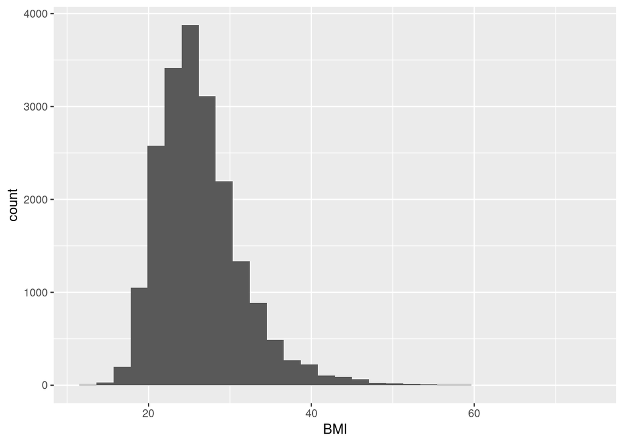

```r
cdc %>%
  ggplot(aes(x=BMI)) +
  geom_histogram()
```

A BMI above 25 suggests that a person is overweight. Using your histogram, approximate the proportion of people who are overweight.

- If you were to select a person from this study at random in a way so that every person in the study had an equal probability of being chosen, then the probability that you would select someone with a health plan is equal to the proportion of people in the study who have a health plan. (This is due to the “Law of Large Numbers” which we’ll learn about later in the course.) Assume that you select a person at random, under the conditions described above. What is the probability that you would select a female? What is the probability that you would select a female who smokes, exercises, and reports good (or better) health? What is the probability that you would select a male who smokes, exercises, and reports good (or better) health?  
  *Note:* You can pipe the output from the summarize command into View(). When you do this, the table will show up as a spreadsheet, and you will be able to carry out the necessary calculations.
- Provide one research question you could ask and answer using this data set.
- Use the data to answer your question, and report the answer.

This lab was written by Ted Galanthay and Matt Thomas, August 2018.